# Final Project Preliminary

November 15, 2020

```r
library(DataComputing)
library(mosaic)
library(readr)
```

### Guiding Question

In what ways can we improve the overall Happiness Score of a country? What are the top three predictors that determine the happiest country? Is there a particular region in the world that’s happier than other regions?

### Becoming Acquantied with the Data Sources

## Uploading Process

To attach my first dataset, I converted my .csv file to a .txt file and uploaded it onto the Stat184FinalProject notebook. Then, I clicked on Import Dataset in Environment and renamed the dataset from “2015” to “WorldHappiness”. To make sure that the dataset was uploaded and saved, I ran the code “View(WorldHappiness)” and I successfully was able to view the dataset table. Next, I tried to extract certain variables to ensure that I can access and manipulate the dataset.

```r
View(WorldHappiness)
WorldHappiness%>%
  select(Country, Region, Happiness.Rank)
```

| Country | Region | Happiness.Rank |
| --- | --- | --- |
| Switzerland | Western Europe | 1 |
| Iceland | Western Europe | 2 |
| Denmark | Western Europe | 3 |
| Norway | Western Europe | 4 |
| Canada | North America | 5 |
| Finland | Western Europe | 6 |
| Netherlands | Western Europe | 7 |
| Sweden | Western Europe | 8 |
| New Zealand | Australia and New Zealand | 9 |
| Australia | Australia and New Zealand | 10 |

[output cut: 148 more lines]

For my next dataset, I used the HTML tables format since the dataset was embedded onto the site. I was successfully able to create a table after loading the dataset using read_html().

```r
library(rvest)
web_page <- "https://www.numbeo.com/crime/rankings_by_country.jsp?title=2015"
SetOfTables <- web_page %>%
  read_html() %>%
  html_nodes(css = "table") %>%
  html_table(fill = TRUE)
length(SetOfTables)
```

```
[1] 2
```

```r
Table3 <- SetOfTables[[2]]
Table3
```

| Rank | Country | Crime Index | Safety Index |
| --- | --- | --- | --- |
| NA | South Sudan | 85.32 | 14.68 |
| NA | Venezuela | 84.07 | 15.93 |
| NA | Guatemala | 79.34 | 20.66 |
| NA | South Africa | 78.44 | 21.56 |
| NA | Afghanistan | 77.34 | 22.66 |
| NA | Guyana | 76.88 | 23.12 |
| NA | Nigeria | 76.60 | 23.40 |
| NA | Trinidad And Tobago | 75.28 | 24.72 |
| NA | Honduras | 74.91 | 25.09 |
| NA | Bahamas | 72.93 | 27.07 |

[output cut: 137 more lines]

I tested to see if I can extract tables from the dataset.

```r
Table3%>%
  select(Country, `Crime Index`, `Safety Index`)
```

| Country | Crime Index | Safety Index |
| --- | --- | --- |
| South Sudan | 85.32 | 14.68 |
| Venezuela | 84.07 | 15.93 |
| Guatemala | 79.34 | 20.66 |
| South Africa | 78.44 | 21.56 |
| Afghanistan | 77.34 | 22.66 |
| Guyana | 76.88 | 23.12 |
| Nigeria | 76.60 | 23.40 |
| Trinidad And Tobago | 75.28 | 24.72 |
| Honduras | 74.91 | 25.09 |
| Bahamas | 72.93 | 27.07 |

[output cut: 137 more lines]

## Where did you find them?

1. I found the World Happiness dataset through Kaggle.
2. I found the Crime/Safety Index by Country dataset through a website called Numbeo. Numbeo is crowd-sourced global database of reported consumer prices, perceived crime rates, quality of health care, among other statistics.

## Who collected/maintains them?

1. The World Happiness is collected through a landmark survey from the Gallup World Poll. The report continues to gain global recognition as governments, organizations and civil society increasingly use happiness indicators to inform their policy-making decisions.
2. The Crime/Safety Index by Country is collected and maintained by Numbeo itself.

## When & Why were they originally collected?

1. The World Happines data started getting collected in 2012. The survey is collected by individuals who live in the country. They’re asked to rate each question on a scale of 1 - 10. Once the data is collected, the Gallup World Poll creates an average value for each variable. It started to get collected as the United Nation started coming together and found that these surveys can help them laws and decision that will benefit their countries and to create awareness to authoritites about how their citizens feel.
2. The Crime/Safety Index by Country first started getting collected in 2012. The reason they started collecting this data is determine what countries are deemed more dangerous and which are deemed more safe and to find out what can be done to improve or maintain the scores.

## What does a case represent in each data source, and how many total cases are available?

1. World Happiness

There are a total of 158 cases in this data set and each case represents the Happiness Rank of each country based off of various variables.

```r
WorldHappiness
```

| Country | Region | Happiness.Rank | Happiness.Score | Standard.Error | Economy..GDP.per.Capita. | Family | Health..Life.Expectancy. | Freedom | Trust..Government.Corruption. | Generosity | Dystopia.Residual |
| --- | --- | --- | --- | --- | --- | --- | --- | --- | --- | --- | --- |
| Switzerland | Western Europe | 1 | 7.587 | 0.03411 | 1.39651 | 1.34951 | 0.94143 | 0.66557 | 0.41978 | 0.29678 | 2.51738 |
| Iceland | Western Europe | 2 | 7.561 | 0.04884 | 1.30232 | 1.40223 | 0.94784 | 0.62877 | 0.14145 | 0.43630 | 2.70201 |
| Denmark | Western Europe | 3 | 7.527 | 0.03328 | 1.32548 | 1.36058 | 0.87464 | 0.64938 | 0.48357 | 0.34139 | 2.49204 |
| Norway | Western Europe | 4 | 7.522 | 0.03880 | 1.45900 | 1.33095 | 0.88521 | 0.66973 | 0.36503 | 0.34699 | 2.46531 |
| Canada | North America | 5 | 7.427 | 0.03553 | 1.32629 | 1.32261 | 0.90563 | 0.63297 | 0.32957 | 0.45811 | 2.45176 |
| Finland | Western Europe | 6 | 7.406 | 0.03140 | 1.29025 | 1.31826 | 0.88911 | 0.64169 | 0.41372 | 0.23351 | 2.61955 |
| Netherlands | Western Europe | 7 | 7.378 | 0.02799 | 1.32944 | 1.28017 | 0.89284 | 0.61576 | 0.31814 | 0.47610 | 2.46570 |
| Sweden | Western Europe | 8 | 7.364 | 0.03157 | 1.33171 | 1.28907 | 0.91087 | 0.65980 | 0.43844 | 0.36262 | 2.37119 |
| New Zealand | Australia and New Zealand | 9 | 7.286 | 0.03371 | 1.25018 | 1.31967 | 0.90837 | 0.63938 | 0.42922 | 0.47501 | 2.26425 |
| Australia | Australia and New Zealand | 10 | 7.284 | 0.04083 | 1.33358 | 1.30923 | 0.93156 | 0.65124 | 0.35637 | 0.43562 | 2.26646 |

[output cut: 148 more lines]

2. Crime Index by Country 2015 There are 147 cases in this dataset and each case represents the crime and safety index according to each country. There is a table for rank, however it is empty. If this table was completed, this data set would represent the ranking (from best to least) according to crime and safety index.

```r
Table3
```

| Rank | Country | Crime Index | Safety Index |
| --- | --- | --- | --- |
| NA | South Sudan | 85.32 | 14.68 |
| NA | Venezuela | 84.07 | 15.93 |
| NA | Guatemala | 79.34 | 20.66 |
| NA | South Africa | 78.44 | 21.56 |
| NA | Afghanistan | 77.34 | 22.66 |
| NA | Guyana | 76.88 | 23.12 |
| NA | Nigeria | 76.60 | 23.40 |
| NA | Trinidad And Tobago | 75.28 | 24.72 |
| NA | Honduras | 74.91 | 25.09 |
| NA | Bahamas | 72.93 | 27.07 |

[output cut: 137 more lines]

## What are some of the variables that you plan to use

The variables I plan to use are basically all of them. However I do plan to remove Standard.Error and Dystopia Residual from the World Happiness data set as I don’t think they are meaningful predictors in calculating overall happiness score. For the final project report, I plan to look more into it before I make a final decision.

### Explore intuition related to the research question

## Create some informative plots and summary statistics

```r
summary(WorldHappiness)
```

```
        Country                                Region   Happiness.Rank   Happiness.Score Standard.Error
 Afghanistan:  1   Sub-Saharan Africa             :40   Min.   :  1.00   Min.   :2.839   Min.   :0.01848
 Albania    :  1   Central and Eastern Europe     :29   1st Qu.: 40.25   1st Qu.:4.526   1st Qu.:0.03727
 Algeria    :  1   Latin America and Caribbean    :22   Median : 79.50   Median :5.232   Median :0.04394
 Angola     :  1   Western Europe                 :21   Mean   : 79.49   Mean   :5.376   Mean   :0.04788
 Argentina  :  1   Middle East and Northern Africa:20   3rd Qu.:118.75   3rd Qu.:6.244   3rd Qu.:0.05230
 Armenia    :  1   Southeastern Asia              : 9   Max.   :158.00   Max.   :7.587   Max.   :0.13693
 (Other)    :152   (Other)                        :17
 Economy..GDP.per.Capita.     Family       Health..Life.Expectancy.    Freedom
 Min.   :0.0000           Min.   :0.0000   Min.   :0.0000           Min.   :0.0000
 1st Qu.:0.5458           1st Qu.:0.8568   1st Qu.:0.4392           1st Qu.:0.3283
 Median :0.9102           Median :1.0295   Median :0.6967           Median :0.4355
 Mean   :0.8461           Mean   :0.9910   Mean   :0.6303           Mean   :0.4286
 3rd Qu.:1.1584           3rd Qu.:1.2144   3rd Qu.:0.8110           3rd Qu.:0.5491
 Max.   :1.6904           Max.   :1.4022   Max.   :1.0252           Max.   :0.6697

 Trust..Government.Corruption.   Generosity     Dystopia.Residual
 Min.   :0.00000               Min.   :0.0000   Min.   :0.3286
 1st Qu.:0.06168               1st Qu.:0.1506   1st Qu.:1.7594
 Median :0.10722               Median :0.2161   Median :2.0954
 Mean   :0.14342               Mean   :0.2373   Mean   :2.0990
 3rd Qu.:0.18025               3rd Qu.:0.3099   3rd Qu.:2.4624
 Max.   :0.55191               Max.   :0.7959   Max.   :3.6021
```

The highest Corruption score is 0.55 which is a lot higher than the mean 0.14. I’m interested to see which country is the most corrupt and from what region they are from. It also seems like the mean Generoisty index is more on the low end and the max is 0.795. I wonder what country has the highest generosity score is and what they are ranked.

```r
summary(Table3)
```

```
   Rank           Country           Crime Index     Safety Index
 Mode:logical   Length:147         Min.   :15.10   Min.   :14.68
 NA's:147       Class :character   1st Qu.:34.98   1st Qu.:40.23
                Mode  :character   Median :45.82   Median :54.18
                                   Mean   :46.85   Mean   :53.15
                                   3rd Qu.:59.77   3rd Qu.:65.02
                                   Max.   :85.32   Max.   :84.90
```

The mean for both Crime and safety seem to be just a few numbers apart. However, a higher safety and a lower crime rate can probably lead to a better happiness score.

```r
MergedTable <-
  Table3%>%
  left_join(WorldHappiness, by = c("Country"))
```

```
Column `Country` joining character vector and factor, coercing into character vector
```

```r
MergedTable
```

| Rank | Country | Crime Index | Safety Index | Region | Happiness.Rank | Happiness.Score | Standard.Error | Economy..GDP.per.Capita. | Family | Health..Life.Expectancy. | Freedom | Trust..Government.Corruption. | Generosity | Dystopia.Residual |
| --- | --- | --- | --- | --- | --- | --- | --- | --- | --- | --- | --- | --- | --- | --- |
| NA | South Sudan | 85.32 | 14.68 | NA | NA | NA | NA | NA | NA | NA | NA | NA | NA | NA |
| NA | Venezuela | 84.07 | 15.93 | Latin America and Caribbean | 23 | 6.810 | 0.06476 | 1.04424 | 1.25596 | 0.72052 | 0.42908 | 0.11069 | 0.05841 | 3.19131 |
| NA | Guatemala | 79.34 | 20.66 | Latin America and Caribbean | 43 | 6.123 | 0.05224 | 0.74553 | 1.04356 | 0.64425 | 0.57733 | 0.09472 | 0.27489 | 2.74255 |
| NA | South Africa | 78.44 | 21.56 | Sub-Saharan Africa | 113 | 4.642 | 0.04585 | 0.92049 | 1.18468 | 0.27688 | 0.33207 | 0.08884 | 0.11973 | 1.71956 |
| NA | Afghanistan | 77.34 | 22.66 | Southern Asia | 153 | 3.575 | 0.03084 | 0.31982 | 0.30285 | 0.30335 | 0.23414 | 0.09719 | 0.36510 | 1.95210 |
| NA | Guyana | 76.88 | 23.12 | NA | NA | NA | NA | NA | NA | NA | NA | NA | NA | NA |
| NA | Nigeria | 76.60 | 23.40 | Sub-Saharan Africa | 78 | 5.268 | 0.04192 | 0.65435 | 0.90432 | 0.16007 | 0.34334 | 0.04030 | 0.27233 | 2.89319 |
| NA | Trinidad And Tobago | 75.28 | 24.72 | NA | NA | NA | NA | NA | NA | NA | NA | NA | NA | NA |
| NA | Honduras | 74.91 | 25.09 | Latin America and Caribbean | 105 | 4.788 | 0.05648 | 0.59532 | 0.95348 | 0.69510 | 0.40148 | 0.06825 | 0.23027 | 1.84408 |
| NA | Bahamas | 72.93 | 27.07 | NA | NA | NA | NA | NA | NA | NA | NA | NA | NA | NA |

[output cut: 137 more lines]

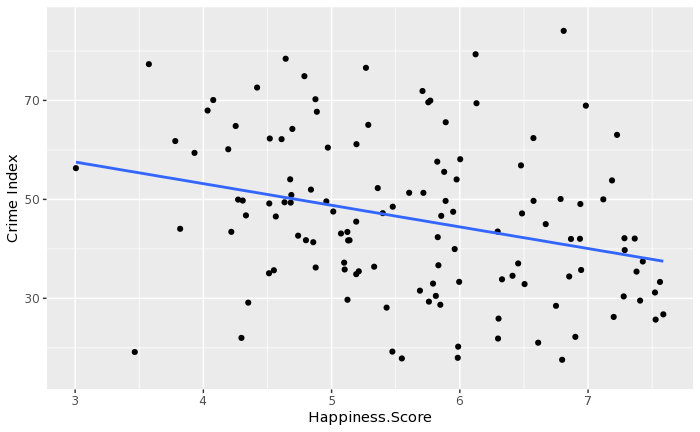

```r
MergedTable%>%
  ggplot(aes(x = Happiness.Score, y = `Crime Index`)) + geom_point()+geom_smooth(method = "lm", se =FALSE)
```

I was interested to see how big Crime plays in Happiness score. It is evident that a lower crime rate can lead to a higher happiness score. However, I’m intrigued by the one value that has a happiness score of about 7 but has the highest crime rate at about 80.

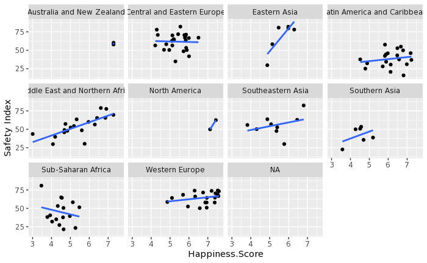

```r
MergedTable%>%
  ggplot(aes(x = Happiness.Score, y = `Safety Index`)) + geom_point()+geom_smooth(method = "lm", se =FALSE) + facet_wrap(~Region)
```

It seems like Eastern Asia is the safest area but doesn’t seem like they have a wonderful Happiness score.

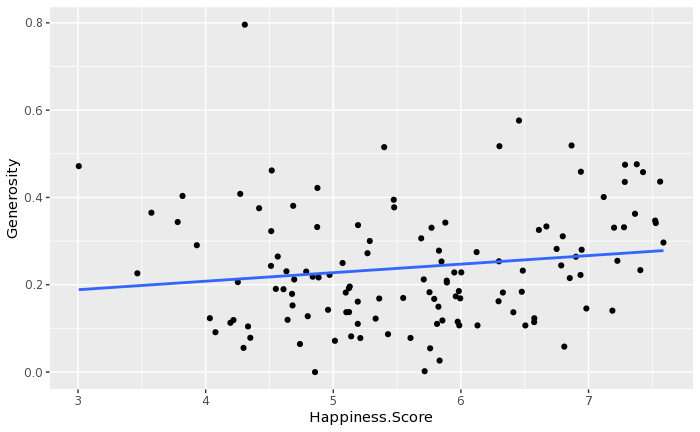

```r
MergedTable%>%
  ggplot(aes(x = Happiness.Score, y = Generosity)) + geom_point() + geom_smooth(method = "lm", se =FALSE)
```